# Lab1

Author

Katie Zhao

```r
library(datasauRus)
```

## QUESTION 1

**Based on the help file, how many rows and how many columns does the datasaurus_dozen file have? What are the variables included in the data frame? Add your responses to your lab report, with relevant code in the associated R code chunk, and free-form text outside of the code chunk.**

```r
?datasaurus_dozen
str(datasaurus_dozen)
```

```
Classes 'tbl_df', 'tbl' and 'data.frame':   1846 obs. of  3 variables:
 $ dataset: chr  "dino" "dino" "dino" "dino" ...
 $ x      : num  55.4 51.5 46.2 42.8 40.8 ...
 $ y      : num  97.2 96 94.5 91.4 88.3 ...
 - attr(*, "spec")=List of 2
  ..$ cols   :List of 3
  .. ..$ dataset: list()
  .. .. ..- attr(*, "class")= chr [1:2] "collector_character" "collector"
  .. ..$ x      : list()
  .. .. ..- attr(*, "class")= chr [1:2] "collector_double" "collector"
  .. ..$ y      : list()
  .. .. ..- attr(*, "class")= chr [1:2] "collector_double" "collector"
  ..$ default: list()
  .. ..- attr(*, "class")= chr [1:2] "collector_guess" "collector"
  ..- attr(*, "class")= chr "col_spec"
```

```r
colnames(datasaurus_dozen)
```

```
[1] "dataset" "x"       "y"
```

Rows: 1846 Columns: 3 Variables: “dataset”, “x”, “y”

```r
table(datasaurus_dozen$dataset)
```

```
      away   bullseye     circle       dino       dots    h_lines high_lines
       142        142        142        142        142        142        142
slant_down   slant_up       star    v_lines wide_lines    x_shape
       142        142        142        142        142        142
```

## QUESTION 2

**Plot y vs. x for the dino dataset. Then, calculate the correlation coefficient between x and y for just this dataset.**

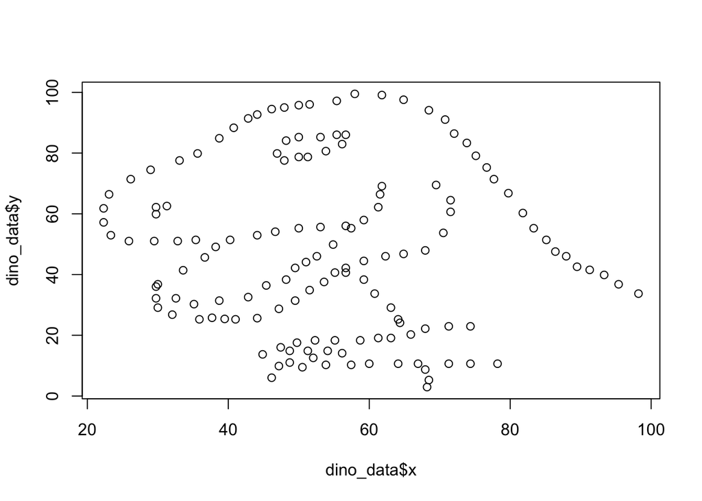

```r
dino_data <- datasaurus_dozen[datasaurus_dozen$dataset == 'dino', ]
plot(dino_data$x, dino_data$y)
```

```r
cor(dino_data$x, dino_data$y)
```

```
[1] -0.06447185
```

## QUESTION 3

**Now try it on your own! Plot y vs. x for the star dataset, another one of the datasaurus_dozen. You can (and should) re-use code we introduced above, just replace the dataset name with the desired dataset. Then, calculate the correlation coefficient between x and y for this dataset. How does this value compare to the r of dino?**

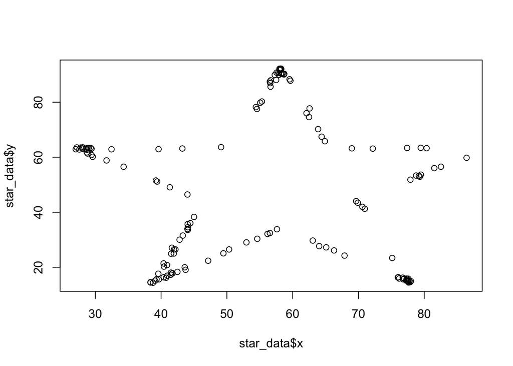

```r
star_data <- datasaurus_dozen[datasaurus_dozen$dataset == "star", ]
plot(star_data$x, star_data$y)
```

```r
cor(star_data$x, star_data$y)
```

```
[1] -0.0629611
```

The correlation coefficient of the “star” dataset between x&y is -0.0629611, which is slightly higher than the correlation coefficient of the “dino” dataset -0.06447185.

## QUESTION 4

**Plot y vs. x for the circle dataset. You can (and should) reuse code we introduced above, just replace the dataset name with the desired dataset. Then, calculate the correlation coefficient between x and y for this dataset. How does this value compare to the r of dino?**

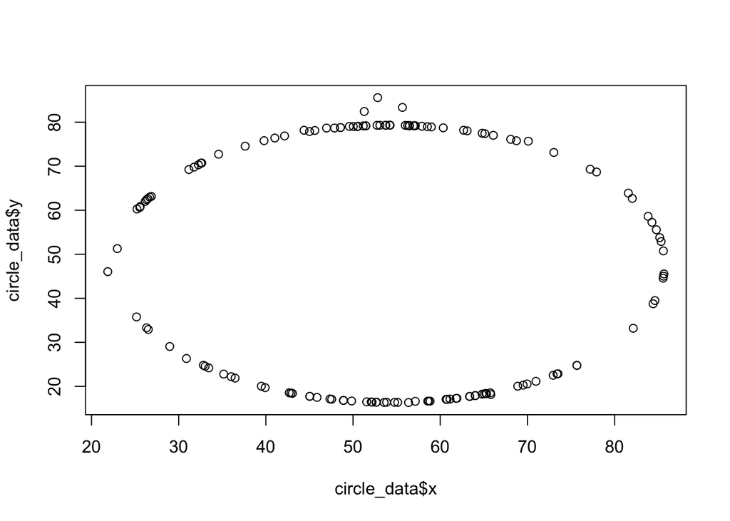

```r
circle_data <- datasaurus_dozen[datasaurus_dozen$dataset == "circle", ]
plot(circle_data$x, circle_data$y)
```

```r
cor(circle_data$x, circle_data$y)
```

```
[1] -0.06834336
```

The correlation coefficient of the “circle” dataset between x&y is -0.06834336, which is slightly lower than the correlation coefficient of the “dino” dataset -0.06447185.

## QUESTION 5:

**Now let’s plot all 13 datasets at once.**

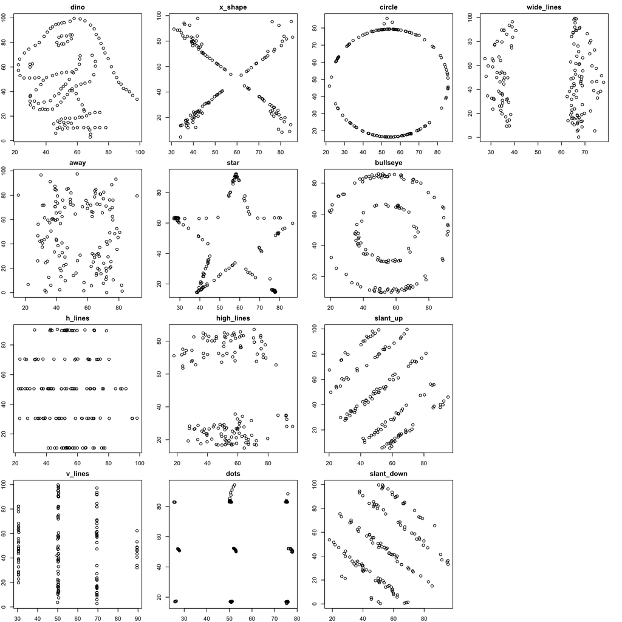

```r
layout(matrix(1:16, nrow=4, ncol=4))
par(mar = c(2,2,2,2))

for(name in unique(datasaurus_dozen$dataset)){
  subset <- datasaurus_dozen[datasaurus_dozen$dataset == name, ]
  plot(subset$x, subset$y, main = name)
}

layout(1)
```

```r
par(mar = c(5,4,4,2) + 0.1)
```

## QUESTION 6

**Finally, we want to calculate the correlation between the `x` and `y` variables for all 13 datasets.**

```r
sapply(unique(datasaurus_dozen$dataset), function(name){
    subset <- datasaurus_dozen[datasaurus_dozen$dataset == name, ]
    return(cor(subset$x, subset$y))
})
```

```
       dino        away     h_lines     v_lines     x_shape        star
-0.06447185 -0.06412835 -0.06171484 -0.06944557 -0.06558334 -0.06296110
 high_lines        dots      circle    bullseye    slant_up  slant_down
-0.06850422 -0.06034144 -0.06834336 -0.06858639 -0.06860921 -0.06897974
 wide_lines
-0.06657523
```